## Assignment 2

### 1

The following code makes a histogram of the `days` variable in the Lake Monona data set.

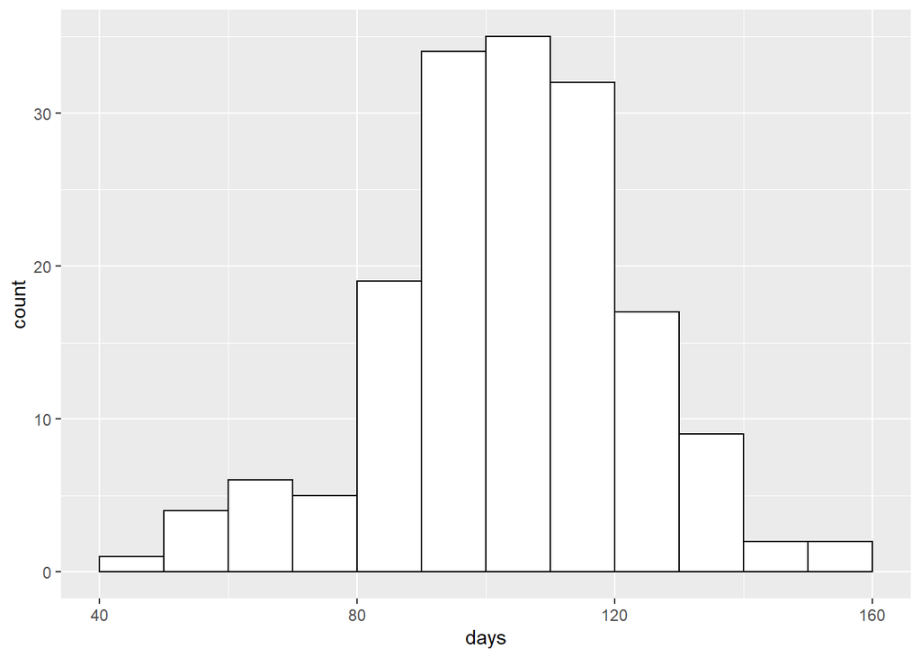

```r
ggplot(monona, aes(x=days)) +
  geom_histogram(boundary=0,binwidth=10,color="black",fill="white")
```

What is the approximate length in days during a typical winter over the past 170 years or so that Lake Monona has been at least 50% covered with ice?

### Response

Approximately 100 days during a typical winter over the past 170 years.

### 2

Modify the code below so that:

- one of the bars is centered at 100 days
- the width of each bar is 7 days
- the fill color is your favorite color
- the x label says “Days Closed with Ice”
- the y label says “total”
- there is a title with words of your choosing

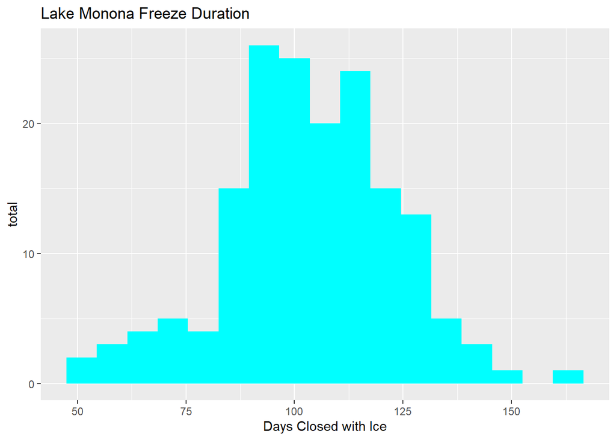

```r
ggplot(monona, aes(x = days)) +
  geom_histogram(center=100, binwidth=7, fill="cyan") +
  xlab("Days Closed with Ice") +
  ylab("total") +
  ggtitle("Lake Monona Freeze Duration")
```

### 3

Code in the next chunk makes a line plot that shows how the variable `days` changes with time (using `year1`).

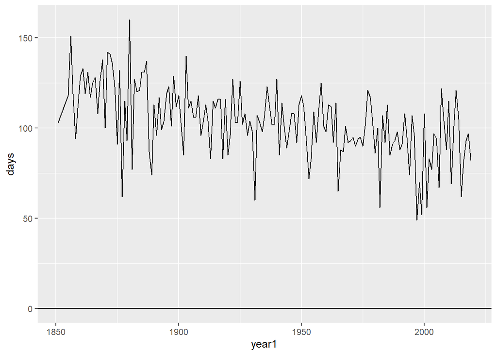

```r
ggplot(monona, aes(x = year1, y = days)) +
  geom_line() +
  geom_hline(yintercept=0)
```

What does the line of code `geom_hline(yintercept=0)` do?

### Response

set the horizontal line at y-intercept = 0

### 4

Modify the code in the following chunk so that:

- There are more descriptive axis labels
- There is an informative plot title
- There is a smooth trend line that has is colored red

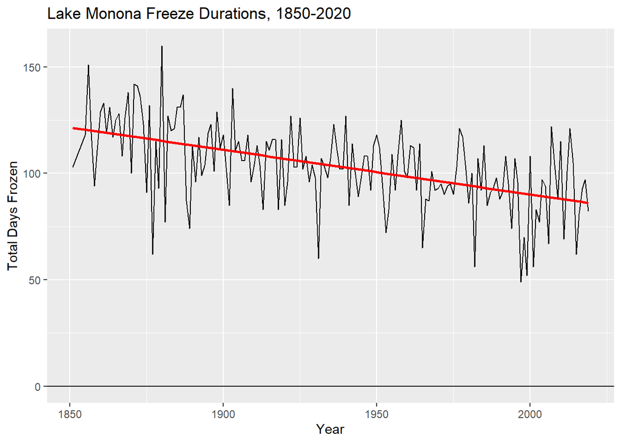

```r
ggplot(monona, aes(x = year1, y = days)) +
  geom_line() +
  geom_hline(yintercept=0) +
  geom_smooth(se=FALSE,color="red", method="lm") +
  xlab("Year") +
  ylab("Total Days Frozen") +
  ggtitle("Lake Monona Freeze Durations, 1850-2020")
```

- Describe the pattern of the trend.
- How long was Lake Monona closed with ice in a typical year near 1850?
- How long was Lake Monona closed with ice in a typical year near the present?
- About how many days less is the period of closure with ice changing per decade?
- Has the change been fairly steady, or has the change been substantially faster or slower in some time periods?

### Response

1.As time goes down, total days frozen of Lake Monona steadily decrease 2.Approximately 120 days 3.Approximately 85 days 4.Approximately 2 days (120-85) / 17 decades (1850~2020) 5.The change has been fairly steady.